# Dashboard: Undergraduate Distance Education in US Schools

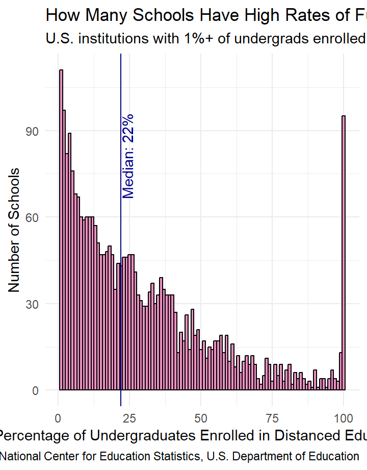

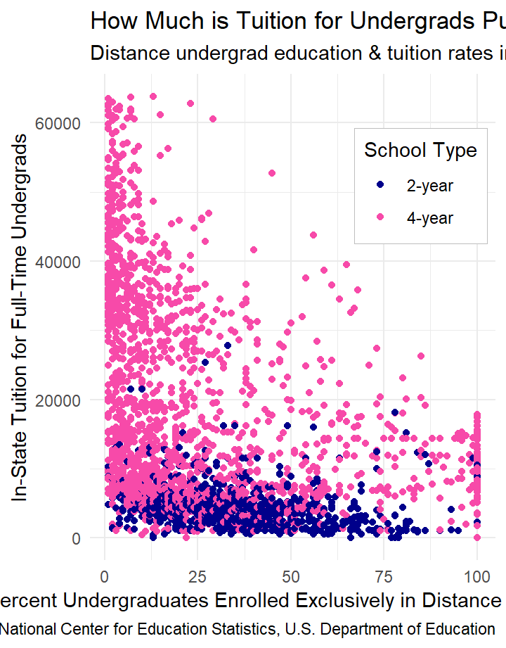

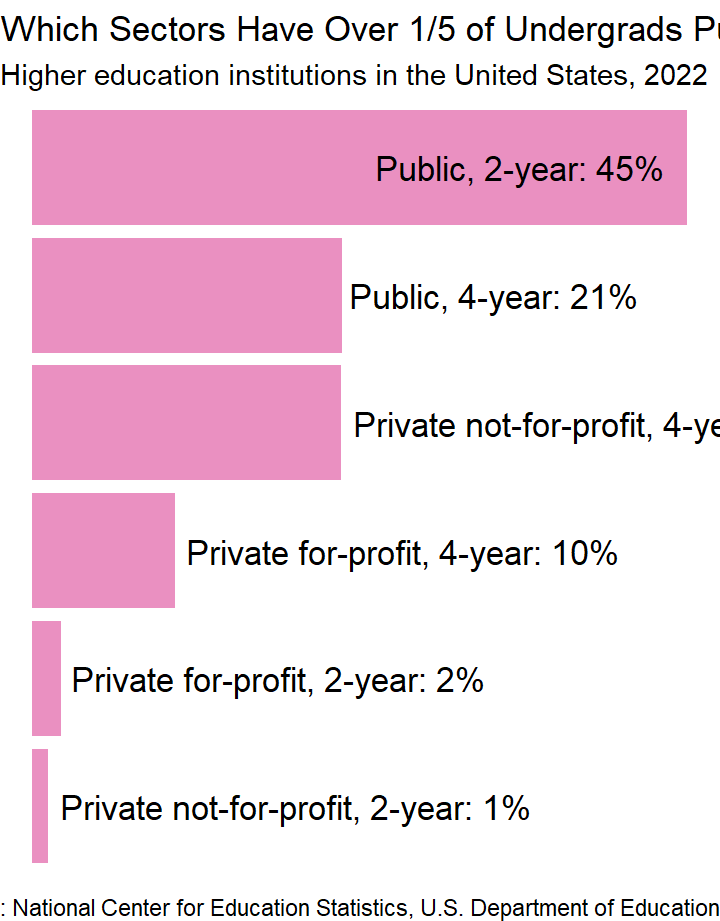

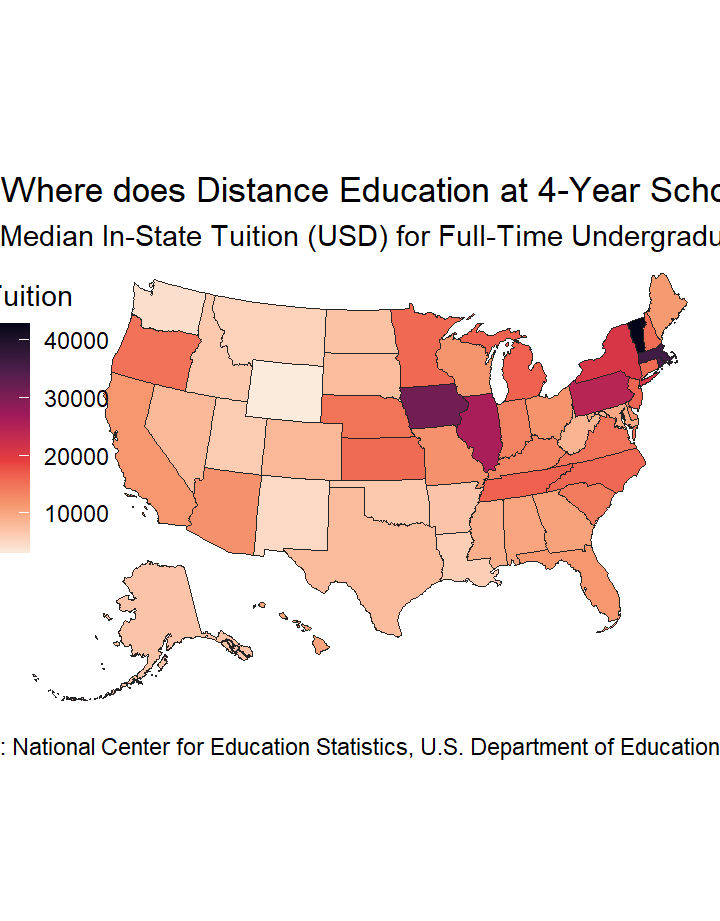

## Intro

You can find the code for this dashboard at https://github.com/peregrinechai/Distance_Education.git

To explore the availability of distance education for undergraduates, I created a custom data set from the Integrated Postsecondary Education Data System. The final data set describes 2,706 institutions which meet the following criteria:

- Grant undergraduate degrees (associate & bachelor degrees),
- Located in the United States (within one of the 50 states or District of Columbia), and
- At least 1 percent of the undergraduate population was enrolled exclusively in distance education during the 2021-22 academic year.

### Key Takeaways

- For schools at or above the median (**22**) percentage of undergraduates pursuing distance education,
  - **45%** of these schools are in the public 2-year sector (community colleges).
  - **66%** of these schools are in the public sector.
- In-state tuition rates are generally **lower** at schools with high percentages of distance education undergraduates.
- 4-year schools are more prevalent than 2-year schools for very high rates of distance education undergraduates (75% and above).
- Tuition rates for in-state undergraduates at 4-year schools are highest in **Vermont** (median of $42,860) and lowest in **Wyoming** (median of $3,150).

### How Many Schools Have High Rates of Distance Ed?

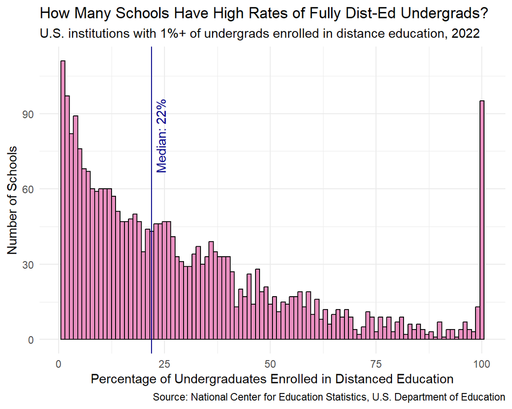

### How Much is Tuition for Distance Ed Undergrads?

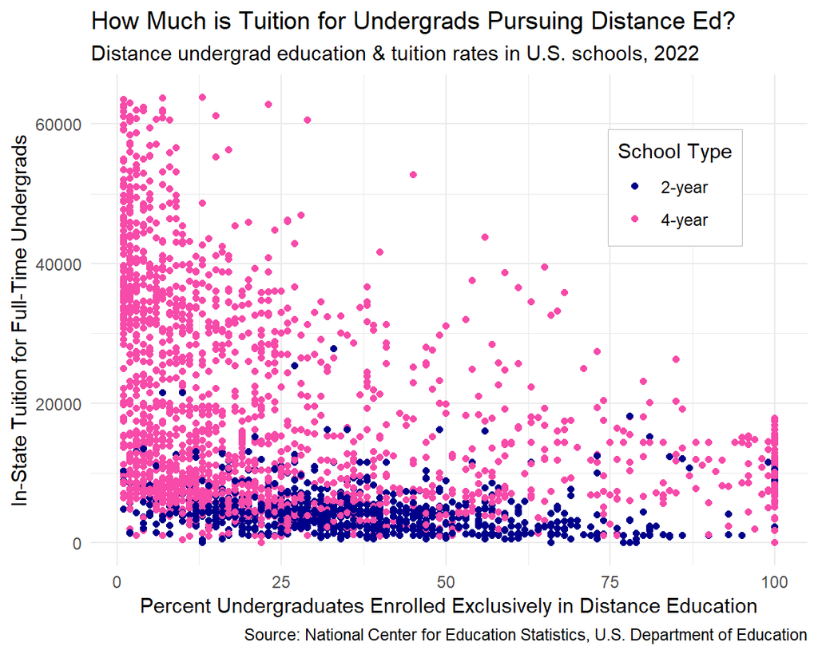

### Which Sectors of Schools Have High Rates of Distance Ed Undergrads?

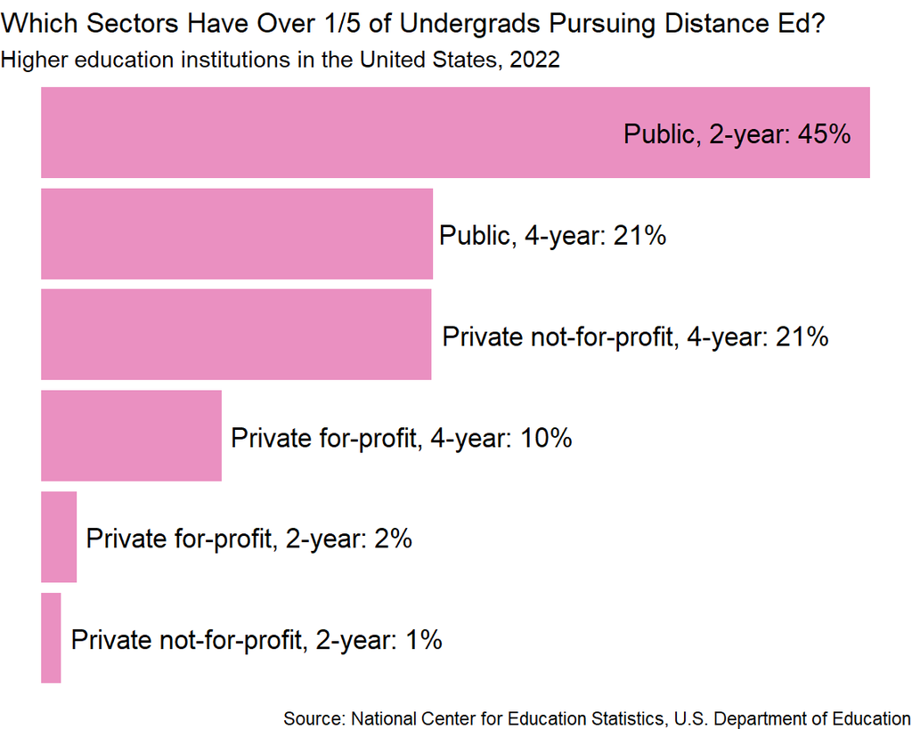

### Where is 4-Year Distance Education the Cheapest?

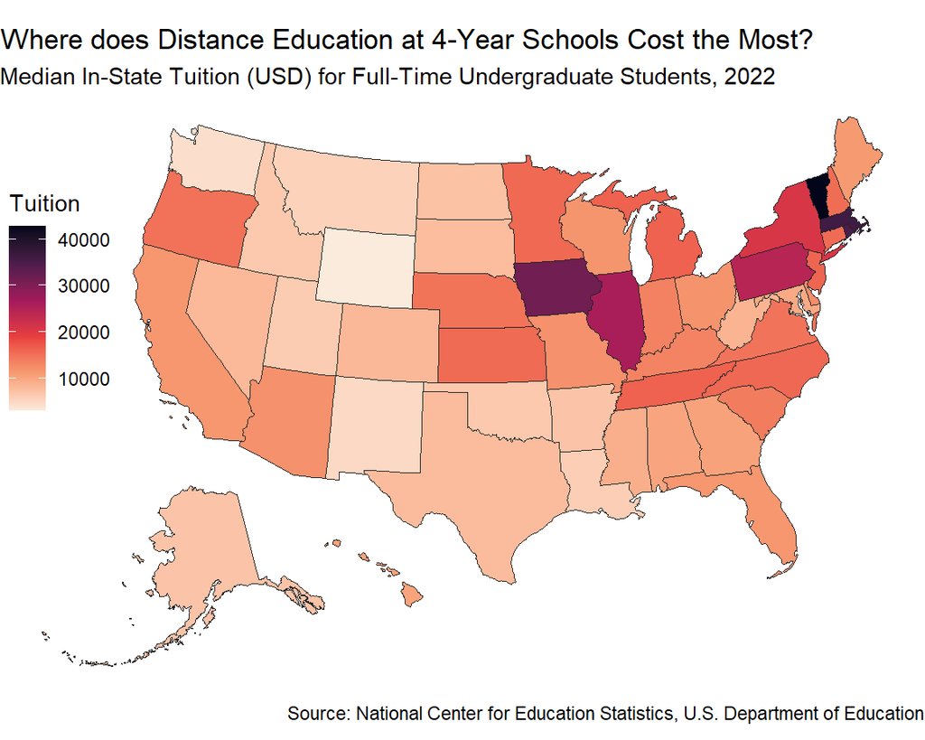